# Part A

# 1. Data Understanding

```python
import numpy as np
import pandas as pd
import matplotlib.pyplot as plt
import seaborn as sns
import warnings
from sklearn.model_selection import train_test_split
from sklearn.neighbors import KNeighborsClassifier
from sklearn.metrics import confusion_matrix, accuracy_score, classification_report, roc_auc_score,roc_curve
from sklearn.preprocessing import StandardScaler,MinMaxScaler, RobustScaler
from sklearn.linear_model import LogisticRegression
from sklearn.model_selection import GridSearchCV
from sklearn.svm import SVC
warnings.filterwarnings('ignore')
%matplotlib inline
```

# A. Read all the 3 CSV files as DataFrame and store them into 3 separate variables

```python
df1 = pd.read_csv('Normal.csv')
df2 =  pd.read_csv('Type_H.csv')
df3 =  pd.read_csv('Type_S.csv')
```

```python
df1.head()
```

|  | P_incidence | P_tilt | L_angle | S_slope | P_radius | S_Degree | Class |
| --- | --- | --- | --- | --- | --- | --- | --- |
| 0 | 38.505273 | 16.964297 | 35.112814 | 21.540976 | 127.632875 | 7.986683 | Normal |
| 1 | 54.920858 | 18.968430 | 51.601455 | 35.952428 | 125.846646 | 2.001642 | Normal |
| 2 | 44.362490 | 8.945435 | 46.902096 | 35.417055 | 129.220682 | 4.994195 | Normal |
| 3 | 48.318931 | 17.452121 | 48.000000 | 30.866809 | 128.980308 | -0.910941 | Normal |
| 4 | 45.701789 | 10.659859 | 42.577846 | 35.041929 | 130.178314 | -3.388910 | Normal |

```python
df2.head()
```

|  | P_incidence | P_tilt | L_angle | S_slope | P_radius | S_Degree | Class |
| --- | --- | --- | --- | --- | --- | --- | --- |
| 0 | 63.027817 | 22.552586 | 39.609117 | 40.475232 | 98.672917 | -0.254400 | Type_H |
| 1 | 39.056951 | 10.060991 | 25.015378 | 28.995960 | 114.405425 | 4.564259 | Type_H |
| 2 | 68.832021 | 22.218482 | 50.092194 | 46.613539 | 105.985135 | -3.530317 | Type_H |
| 3 | 69.297008 | 24.652878 | 44.311238 | 44.644130 | 101.868495 | 11.211523 | Type_H |
| 4 | 49.712859 | 9.652075 | 28.317406 | 40.060784 | 108.168725 | 7.918501 | Type_H |

```python
df3.head()
```

|  | P_incidence | P_tilt | L_angle | S_slope | P_radius | S_Degree | Class |
| --- | --- | --- | --- | --- | --- | --- | --- |
| 0 | 74.377678 | 32.053104 | 78.772013 | 42.324573 | 143.560690 | 56.125906 | Type_S |
| 1 | 89.680567 | 32.704435 | 83.130732 | 56.976132 | 129.955476 | 92.027277 | Type_S |
| 2 | 44.529051 | 9.433234 | 52.000000 | 35.095817 | 134.711772 | 29.106575 | Type_S |
| 3 | 77.690577 | 21.380645 | 64.429442 | 56.309932 | 114.818751 | 26.931841 | Type_S |
| 4 | 76.147212 | 21.936186 | 82.961502 | 54.211027 | 123.932010 | 10.431972 | Type_S |

# B. Print Shape and columns of all the 3 DataFrames

```python
print("Shape of Normal Dataframe", df1.shape)
print("Shape of Type_H Dataframe", df2.shape)
print("Shape of Type_S Dataframe", df3.shape)
```

```
Shape of Normal Dataframe (100, 7)
Shape of Type_H Dataframe (60, 7)
Shape of Type_S Dataframe (150, 7)
```

```python
print('Normal Dataframe column: ', df1.columns)
print('Type_H Dataframe column: ', df2.columns)
print('Type_S Dataframe column: ', df3.columns)
```

```
Normal Dataframe column:  Index(['P_incidence', 'P_tilt', 'L_angle', 'S_slope', 'P_radius', 'S_Degree',
       'Class'],
      dtype='object')
Type_H Dataframe column:  Index(['P_incidence', 'P_tilt', 'L_angle', 'S_slope', 'P_radius', 'S_Degree',
       'Class'],
      dtype='object')
Type_S Dataframe column:  Index(['P_incidence', 'P_tilt', 'L_angle', 'S_slope', 'P_radius', 'S_Degree',
       'Class'],
      dtype='object')
```

# C. Compare Column names of all the 3 DataFrames and clearly write observations.

#### In all three dataset, we have 6 feature('P_incidence', 'P_tilt', 'L_angle', 'S_slope', 'P_radius', 'S_Degree',) and 1 target variables(Class)

#### Data are segregated into different file based on class variable.

# D. Print DataTypes of all the 3 DataFrames.

```python
print("Dtype of normal class : \n", df1.dtypes)
print('--------------------------------------------')
print("Dtype of Type H class : \n", df2.dtypes)
print('--------------------------------------------')
print("Dtype of Type C class : \n", df3.dtypes)
print('--------------------------------------------')
```

```
Dtype of normal class :
 P_incidence    float64
P_tilt         float64
L_angle        float64
S_slope        float64
P_radius       float64
S_Degree       float64
Class           object
dtype: object
--------------------------------------------
Dtype of Type H class :
 P_incidence    float64
P_tilt         float64
L_angle        float64
S_slope        float64
P_radius       float64
S_Degree       float64
Class           object
dtype: object
--------------------------------------------
Dtype of Type C class :
 P_incidence    float64
P_tilt         float64
L_angle        float64
S_slope        float64
P_radius       float64
S_Degree       float64
Class           object
dtype: object
--------------------------------------------
```

# E.Observe and share variation in ‘Class’ feature of all the 3 DaraFrames

```python
df1.Class.value_counts(normalize=True)*100
```

```
Normal    73.0
Nrmal     27.0
Name: Class, dtype: float64
```

```python
df2.Class.value_counts(normalize=True)*100
```

```
Type_H    61.666667
type_h    38.333333
Name: Class, dtype: float64
```

```python
df3.Class.value_counts(normalize=True)*100
```

```
Type_S    88.666667
tp_s      11.333333
Name: Class, dtype: float64
```

#### It clearly shows that there is a variation in the class feature. Same category are written in different style/different word.Some time it is written in capital/small case, sometime small short abbreviation. In the dataframe 1, Spellings are different for "Normal"

# 2. Data Preparation and Exploration:

### A. Unify all the variations in ‘Class’ feature for all the 3 DataFrames

```python
df1.Class.replace("Nrmal", "Normal", inplace=True);
df1.Class.value_counts(normalize=True)*100
```

```
Normal    100.0
Name: Class, dtype: float64
```

```python
df2.Class.replace("Type_H", "type_h", inplace=True);
df2.Class.value_counts(normalize=True)*100
```

```
type_h    100.0
Name: Class, dtype: float64
```

```python
df3.Class.replace(["tp_s", 'Type_S'], "type_s", inplace=True);
df3.Class.value_counts(normalize=True)*100
```

```
type_s    100.0
Name: Class, dtype: float64
```

# B. Combine all the 3 DataFrames to form a single DataFrame

```python
df1 = df1.append([df2, df3])
df1.reset_index(inplace=True, drop=True)
```

```python
df1.Class.value_counts(normalize=True)*100
```

```
type_s    48.387097
Normal    32.258065
type_h    19.354839
Name: Class, dtype: float64
```

# C. Print 5 random samples of this DataFrame

```python
df1.sample(5)
```

|  | P_incidence | P_tilt | L_angle | S_slope | P_radius | S_Degree | Class |
| --- | --- | --- | --- | --- | --- | --- | --- |
| 55 | 48.170746 | 9.594217 | 39.710920 | 38.576530 | 135.623310 | 5.360051 | Normal |
| 274 | 61.411737 | 25.384364 | 39.096869 | 36.027373 | 103.404597 | 21.843407 | type_s |
| 125 | 54.124920 | 26.650489 | 35.329747 | 27.474432 | 121.447011 | 1.571205 | type_h |
| 144 | 56.030218 | 16.297915 | 62.275275 | 39.732303 | 114.023117 | -2.325684 | type_h |
| 72 | 53.683380 | 13.447022 | 41.584297 | 40.236358 | 113.913703 | 2.737035 | Normal |

# D. Print Feature-wise percentage of Null values

```python
(df1.isna().sum()/df1.isna().count())*100
```

```
P_incidence    0.0
P_tilt         0.0
L_angle        0.0
S_slope        0.0
P_radius       0.0
S_Degree       0.0
Class          0.0
dtype: float64
```

# E. Check 5-point summary of the new DataFrame.

```python
df1.describe().T
```

|  | count | mean | std | min | 25% | 50% | 75% | max |
| --- | --- | --- | --- | --- | --- | --- | --- | --- |
| P_incidence | 310.0 | 60.496653 | 17.236520 | 26.147921 | 46.430294 | 58.691038 | 72.877696 | 129.834041 |
| P_tilt | 310.0 | 17.542822 | 10.008330 | -6.554948 | 10.667069 | 16.357689 | 22.120395 | 49.431864 |
| L_angle | 310.0 | 51.930930 | 18.554064 | 14.000000 | 37.000000 | 49.562398 | 63.000000 | 125.742385 |
| S_slope | 310.0 | 42.953831 | 13.423102 | 13.366931 | 33.347122 | 42.404912 | 52.695888 | 121.429566 |
| P_radius | 310.0 | 117.920655 | 13.317377 | 70.082575 | 110.709196 | 118.268178 | 125.467674 | 163.071041 |
| S_Degree | 310.0 | 26.296694 | 37.559027 | -11.058179 | 1.603727 | 11.767934 | 41.287352 | 418.543082 |

```
P_incidence Q3  72.87769551 Q1: 46.43029421 (Q3-Q1)  26.447401299999996 Q3 + 1.5*(Q3-Q1)  112.54879745999999
P_tilt Q3  22.12039474 Q1: 10.66706906 (Q3-Q1)  11.453325679999999 Q3 + 1.5*(Q3-Q1)  39.30038326
L_angle Q3  62.99999999 Q1: 37.0 (Q3-Q1)  25.99999999 Q3 + 1.5*(Q3-Q1)  101.99999997500001
S_slope Q3  52.695888355 Q1: 33.3471220125 (Q3-Q1)  19.3487663425 Q3 + 1.5*(Q3-Q1)  81.71903786875001
P_radius Q3  125.467674425 Q1: 110.7091963 (Q3-Q1)  14.758478124999996 Q3 + 1.5*(Q3-Q1)  147.6053916125
S_Degree Q3  41.287351962500004 Q1: 1.60372667375 (Q3-Q1)  39.68362528875 Q3 + 1.5*(Q3-Q1)  100.812789895625
```

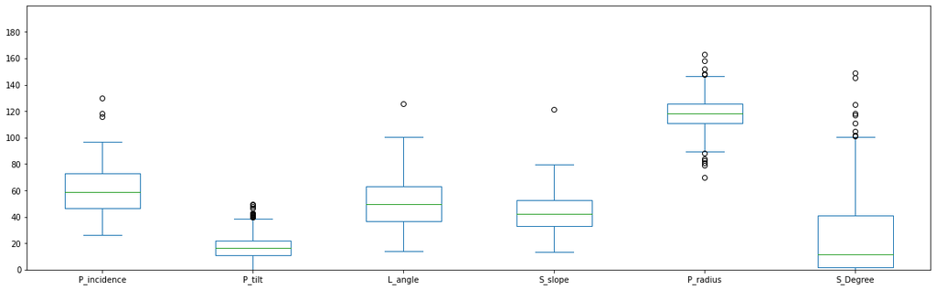

```python
for column in df1.columns[:-1]:
    IQR3 = df1[column].quantile(0.75)
    IQR1 = df1[column].quantile(0.25)
    print(column, 'Q3 ', IQR3, 'Q1:', IQR1, '(Q3-Q1) ', IQR3-IQR1, 'Q3 + 1.5*(Q3-Q1) ', IQR3+1.5*(IQR3-IQR1))

df1.plot(kind="box", figsize=(20,6))
plt.yticks(np.arange(0, 200, 20))
plt.ylim(0,200)
plt.show()
```

### 6) S_Degree

#### 6.1) Mean is greater than median

#### 6.2) Data is rightly skewed.

#### 6.3) Data have -ve value.

#### 6.4) 75% of the value is below 50 and max value is 418.543082

#### 5.3) There must be large outliers present. Since IQR3+ 1.5*(IQR3-IQR1) near to 100 which is less than 418.543082 value (max value)

# 3. Data Analysis:

# A. Visualize a heatmap to understand correlation between all features

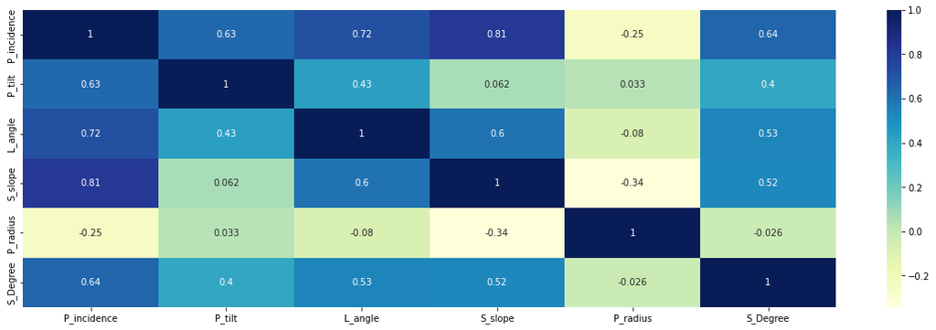

```python
plt.figure(figsize=(20,6))
sns.heatmap(df1.corr(), annot=True,cmap="YlGnBu")
```

# Suppose Cutoff for strong is 0.60

### A. Stronger Correlation

### 1) between P_incidence, P_tilt having 0.63 correlation value

### 2) P_incidence and L_angle having 0.72 correlation value

### 3) P_incidence and S_slope having 0.81 correlation value

### 4) P_incidence and S_Degree having 0.64 correlation value

### 5) L_angle and S_slope having 0.6 correlation value

# Suppose Cutoff for weaker is below -0.2

### B. Weak Correlation

### 1) P_incidence and P_radius having -0.25 correlation value

### 2) S_slope and P_radius having -0.34 correlation value

# C. Visualize a pairplot with 3 classes distinguished by colors and share insights.

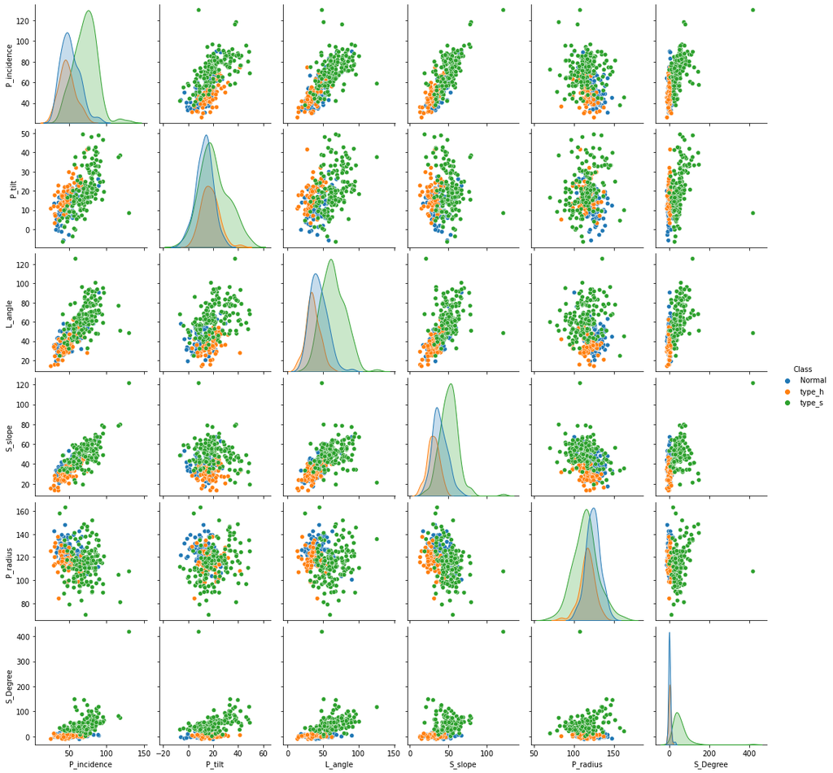

```python
sns.pairplot(df1, hue='Class', diag_kind="kde")
```

#### Distribution of Class are not same

#### type_s has more variance than Normal

#### Normal has more variance than type_h

# D. Visualize a jointplot for ‘P_incidence’ and ‘S_slope’ and share insights.

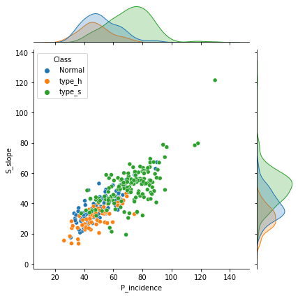

```python
sns.jointplot(data=df1, x='P_incidence', y='S_slope', hue='Class')
```

### There is String correlation between P_incidenc and S_slope

### There are some outliers nearby 120 X-axis

# E. Visualize a boxplot to check distribution of the features and share insights.

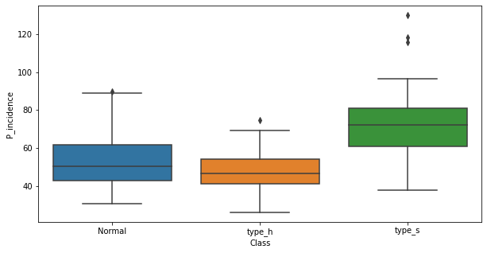

```python
plt.figure(figsize=(10,5))
sns.boxplot(data= df1,x='Class', y='P_incidence')
```

### P_incidence has higher variation of Type_s

### Outliers are present all the 3 Class.

### P_incidence Normal class variance is slightly higer than type_h

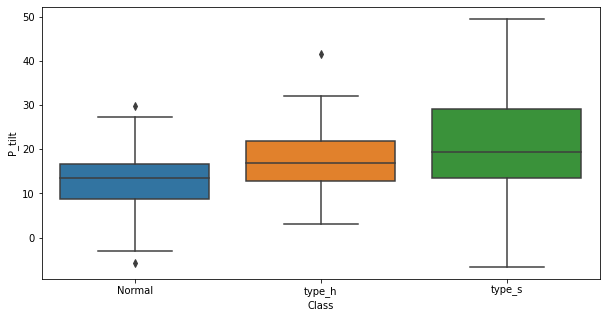

```python
plt.figure(figsize=(10,5))
sns.boxplot(data= df1,x='Class', y='P_tilt')
```

### P_tilt Normal class category has outlier present at both end

### Type_h has outlier present at right side

### Type_s has no outliers.

### P_tilt has higher value of type_s

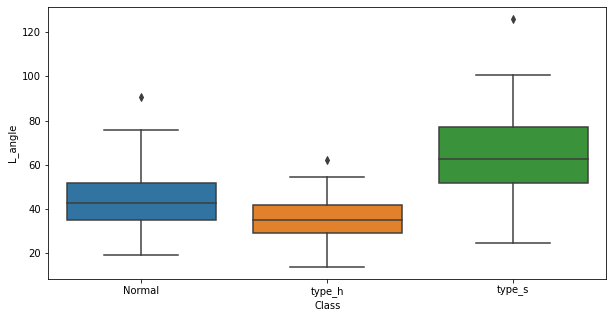

```python
plt.figure(figsize=(10,5))
sns.boxplot(data= df1,x='Class', y='L_angle')
```

### L_Angle has higher value for Type_S Class

### outlier are present for each class.

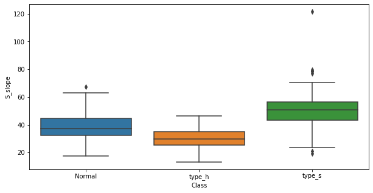

```python
plt.figure(figsize=(10,5))
sns.boxplot(data= df1,x='Class', y='S_slope')
```

### S_slope has higher value for Type_S Class

### Higher outlier are present for type_s class.

### No outliers are present in type_h

### Normal class has very few outliers

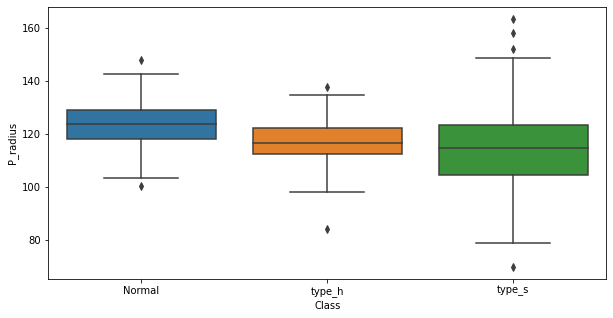

```python
plt.figure(figsize=(10,5))
sns.boxplot(data= df1,x='Class', y='P_radius')
```

### P_radius value is more for Normal class

### Outliers are present in all 3 class

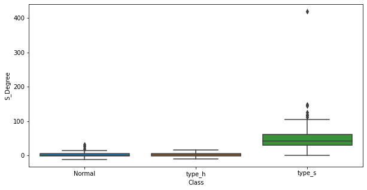

```python
plt.figure(figsize=(10,5))
sns.boxplot(data= df1,x='Class', y='S_Degree')
```

### S_Degree value is more for type_s

### Outliers are present for Normal and type_s class

### No outliers are present for type_h

# 4. Model Building:

```python
def printPerformanceMeasurementParameter(model, X_train_p, y_train_p, X_test_p, y_test_p, y_class_Label_p, y_class_Pre_Label_p):
    model.fit(X_train_p, y_train_p)
    training_acc= model.score(X_train_p, y_train_p);
    testing_acc= model.score(X_test_p, y_test_p);

    if isinstance(model, KNeighborsClassifier) and len(y_class_Label_p)>2:
        testing_prob= model.predict_proba(X_test_p)
        auc = roc_auc_score(y_test_p, testing_prob, multi_class='ovr')
    else:
        testing_prob= model.predict_proba(X_test_p)[:,1]
        auc = roc_auc_score(y_test_p, testing_prob, )

    y_predict = model.predict(X_test_p)
    print("trainig accuracy", training_acc)
    print("testing accuracy", testing_acc)
    print("auc", auc)
    print("Classifier Report ")
    print(classification_report(y_test_p, y_predict));
    print("----------------------------------")
    print("Confusion matrix")
    cm = confusion_matrix(y_test_p, y_predict, labels=y_class_Label_p);
    df_cm = pd.DataFrame(cm, index = [i for i in y_class_Label_p],
                  columns = [i for i in y_class_Pre_Label_p])
    plt.figure(figsize = (7,5));
    sns.heatmap(df_cm, annot=True, fmt='g');
    return training_acc, testing_acc, y_predict, cm, auc
```

### A. Split data into X and Y.

```python
X= df1.drop('Class', axis=1)
y= df1['Class']
```

### B. Split data into train and test with 80:20 proportion.

```python
X_train, X_test, y_train, y_test = train_test_split(X,y, test_size=0.20, random_state=1)
```

# C Train a Supervised Learning Classification base model using KNN classifier and D. Print all the possible performance metrics for both train and test data.

```python
y_class_Label = ['Normal', "type_h", "type_s"]
y_class_Pre_Label= ['Predicted Normal', "Predicted type_h", "Predicted type_s"]
```

### Without Scaling

```
Calculating Report with No Scaling
trainig accuracy 0.8911290322580645
testing accuracy 0.8387096774193549
auc 0.9360380341617663
Classifier Report
              precision    recall  f1-score   support

      Normal       0.67      0.89      0.76        18
      type_h       0.88      0.64      0.74        11
      type_s       0.97      0.88      0.92        33

    accuracy                           0.84        62
   macro avg       0.84      0.80      0.81        62
weighted avg       0.86      0.84      0.84        62

----------------------------------
Confusion matrix
```

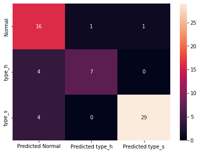

```python
noScale_df = pd.DataFrame()
knn = KNeighborsClassifier(n_neighbors=5)
print("Calculating Report with No Scaling")
training_acc, testing_acc, y_predict, cm, auc = printPerformanceMeasurementParameter(knn, X_train, y_train, X_test, y_test, y_class_Label, y_class_Pre_Label)
noScale_df[['Model', 'Accuracy','AUC']]= [['No Scaling', testing_acc,  auc]]
```

#### Scale the feature using the below Scaler and check the performance

#### Which ever give higher performance , will chose the scaler and proceed

Prepare model using StandardScaler

```
trainig accuracy 0.8467741935483871
testing accuracy 0.7258064516129032
auc 0.8860708163446501
Classifier Report
              precision    recall  f1-score   support

      Normal       0.57      0.67      0.62        18
      type_h       0.67      0.73      0.70        11
      type_s       0.86      0.76      0.81        33

    accuracy                           0.73        62
   macro avg       0.70      0.72      0.71        62
weighted avg       0.74      0.73      0.73        62

----------------------------------
Confusion matrix
```

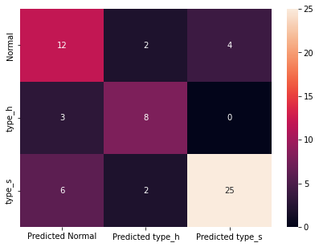

```python
scale_df = pd.DataFrame()
stds =StandardScaler()
X_train_scaled = stds.fit_transform(X_train)
X_test_scaled = stds.transform(X_test)
###
knn = KNeighborsClassifier(n_neighbors=5)
training_acc, testing_acc, y_predict, cm, auc = printPerformanceMeasurementParameter(knn, X_train_scaled, y_train, X_test_scaled, y_test, y_class_Label, y_class_Pre_Label)
scale_df[['Model', 'Accuracy','AUC']]= [['Standar Scaler', testing_acc,  auc]]
```

Prepare model using MinMaxScaler

```
trainig accuracy 0.8104838709677419
testing accuracy 0.6935483870967742
auc 0.864637756879136
Classifier Report
              precision    recall  f1-score   support

      Normal       0.55      0.67      0.60        18
      type_h       0.64      0.64      0.64        11
      type_s       0.83      0.73      0.77        33

    accuracy                           0.69        62
   macro avg       0.67      0.68      0.67        62
weighted avg       0.71      0.69      0.70        62

----------------------------------
Confusion matrix
```

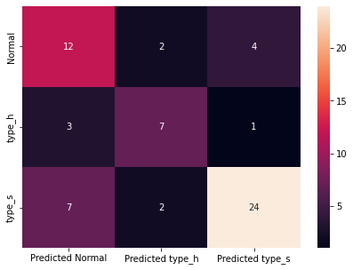

```python
minMaxscale_df = pd.DataFrame()
minMax =MinMaxScaler()
X_train_minMax_scaled = minMax.fit_transform(X_train)
X_test_minMax_scaled = minMax.transform(X_test)
knn = KNeighborsClassifier(n_neighbors=5)
training_acc, testing_acc, y_predict, cm, auc = printPerformanceMeasurementParameter(knn, X_train_minMax_scaled, y_train, X_test_minMax_scaled, y_test,  y_class_Label, y_class_Pre_Label)
minMaxscale_df[['Model', 'Accuracy','AUC']]= [['MinMax Scaler', testing_acc, auc]]
```

### Prepare model using RobustScaler

```
trainig accuracy 0.8709677419354839
testing accuracy 0.7580645161290323
auc 0.8924189494676312
Classifier Report
              precision    recall  f1-score   support

      Normal       0.59      0.72      0.65        18
      type_h       0.78      0.64      0.70        11
      type_s       0.87      0.82      0.84        33

    accuracy                           0.76        62
   macro avg       0.75      0.73      0.73        62
weighted avg       0.77      0.76      0.76        62

----------------------------------
Confusion matrix
```

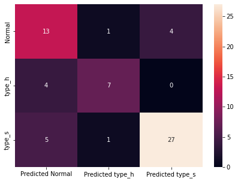

```python
robScale_df = pd.DataFrame()
robustScaler =RobustScaler()
X_train_rob_scaled = robustScaler.fit_transform(X_train)
X_test_rob_scaled = robustScaler.transform(X_test)

knn = KNeighborsClassifier(n_neighbors=5)
training_acc, testing_acc, y_predict, cm, auc = printPerformanceMeasurementParameter(knn, X_train_rob_scaled, y_train, X_test_rob_scaled, y_test, y_class_Label, y_class_Pre_Label)
robScale_df[['Model', 'Accuracy','AUC']]= [['Robust Scaler', testing_acc, auc]]
```

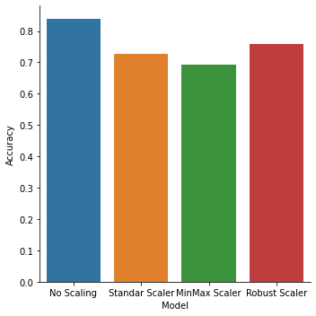

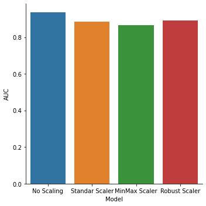

```python
noScale_df= noScale_df.append([scale_df, minMaxscale_df, robScale_df])
sns.catplot(x="Model", y="Accuracy", kind="bar", data=noScale_df)
plt.show()
sns.catplot(x="Model", y="AUC", kind="bar", data=noScale_df)
```

### Observation:

## Accuracy and auc score( accuracy 0.8387096774193549 , auc 0.9360380341617663) is high with no Scaling data. Hence proceding with no scaling data.

```python
### Finding the value of best K value
```

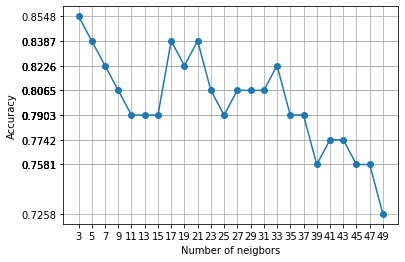

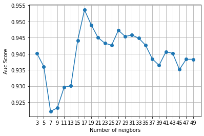

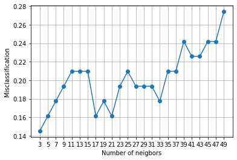

```python
N_neigbours = list(np.arange(3,50,2))
score = []
auc = []
misclassification = []
for n in N_neigbours:
    knn = KNeighborsClassifier(n_neighbors=n )
    knn.fit(X_train, y_train.values.ravel())
    score.append(knn.score(X_test, y_test))
    auc.append(roc_auc_score(y_test, knn.predict_proba(X_test), multi_class='ovr'))
    misclassification.append(np.mean(knn.predict(X_test) != y_test))


plt.plot(N_neigbours, score,'o-');
plt.xticks(N_neigbours);
plt.xlabel("Number of neigbors")
plt.ylabel("Accuracy")
plt.yticks(score);###
plt.grid()
plt.show()

#
plt.plot(N_neigbours, auc,'o-');
plt.xticks(N_neigbours);
plt.xlabel("Number of neigbors")
plt.ylabel("Auc Score")
plt.grid()
plt.show()

#
plt.plot(N_neigbours, misclassification,'o-');
plt.xticks(N_neigbours);
plt.xlabel("Number of neigbors")
plt.ylabel("Misclassification")
plt.grid()
plt.show()
```

### This plot shows that 3 th Neighbour is giving best performance in KNN Classifier with default parametes. Lets do GridSearchCV with more parameters with no scaling data

```python
hyper_parameters = dict(n_neighbors = N_neigbours, weights= ['distance', 'uniform'],p = [1,2])
```

```python
model = GridSearchCV(KNeighborsClassifier(), hyper_parameters, cv=10, scoring='accuracy', return_train_score=False,verbose=1)
model.fit(X_train, y_train.values.ravel())
y_pred_no_scale = model.predict(X_test);
#Check performance using accuracy
print("Tesing accuracy ",accuracy_score(y_test, y_pred_no_scale))

print("Auc Score ", roc_auc_score(y_test, model.predict_proba(X_test), multi_class='ovr'))
#Best Hyperparameters Value
print("Best Parameters : ",model.best_params_)
print("Best score : ",model.best_score_)
print('Best n_neighbors:', model.best_estimator_.get_params()['n_neighbors'])
print('Best weight:', model.best_estimator_.get_params()['weights'])
```

```
Fitting 10 folds for each of 96 candidates, totalling 960 fits
Tesing accuracy  0.8548387096774194
Auc Score  0.9374982925946415
Best Parameters :  {'n_neighbors': 7, 'p': 1, 'weights': 'distance'}
Best score :  0.851
Best n_neighbors: 7
Best weight: distance
```

### By performing hypertuning we find the best value of neigbor as 7 with weight as distance and p=1

### Hence going with GridSearchCV parameters

```
trainig accuracy 1.0
testing accuracy 0.8548387096774194
auc 0.9374982925946415
Classifier Report
              precision    recall  f1-score   support

      Normal       0.71      0.83      0.77        18
      type_h       0.90      0.82      0.86        11
      type_s       0.94      0.88      0.91        33

    accuracy                           0.85        62
   macro avg       0.85      0.84      0.84        62
weighted avg       0.86      0.85      0.86        62

----------------------------------
Confusion matrix
```

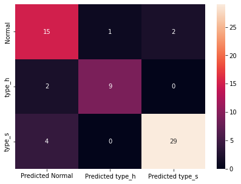

```python
knn = KNeighborsClassifier(n_neighbors=7, weights = 'distance', p=1)
training_acc, testing_acc, y_predict, cm, auc = printPerformanceMeasurementParameter(knn, X_train, y_train, X_test, y_test, y_class_Label, y_class_Pre_Label)
```

### Recall of type_h has been increased from 64% to 82%

### F-score of type_h has been increased from 74% to 86%

# C. Clearly state which parameters contributed most to improve model performance

As calculated above the best parameter are {'n_neighbors': 7, 'p': 1, 'weights': 'distance'} giving accuracy of 85% and good AUC score i.e 93.7%

# PART B:

# 1. Data Understanding and Preparation

### A. Read both the Datasets ‘Data1’ and ‘Data 2’ as DataFrame and store them into two separate variables

```python
df_data1 = pd.read_csv('Data1.csv')
df_data2 = pd.read_csv('Data2.csv')
```

### B. Print shape and Column Names and DataTypes of both the Dataframe

```python
print('Data 1 Shape : \n', df_data1.shape)
print('-----------------------------------------------')
print('Data 1 column Name : \n', df_data1.columns)
print('-----------------------------------------------')
print('Data 1 Dtype : \n', df_data1.dtypes)

print('-----------------------------------------------')
print('-----------------------------------------------')
print('-----------------------------------------------')
print('Data 2 Shape : \n', df_data2.shape)
print('-----------------------------------------------')
print('Data 2 column Name : \n', df_data2.columns)
print('-----------------------------------------------')
print('Data 2 Dtype : \n', df_data2.dtypes)
```

```
Data 1 Shape :
 (5000, 8)
-----------------------------------------------
Data 1 column Name :
 Index(['ID', 'Age', 'CustomerSince', 'HighestSpend', 'ZipCode', 'HiddenScore',
       'MonthlyAverageSpend', 'Level'],
      dtype='object')
-----------------------------------------------
Data 1 Dtype :
 ID                       int64
Age                      int64
CustomerSince            int64
HighestSpend             int64
ZipCode                  int64
HiddenScore              int64
MonthlyAverageSpend    float64
Level                    int64
dtype: object
-----------------------------------------------
-----------------------------------------------
-----------------------------------------------
Data 2 Shape :
 (5000, 7)
-----------------------------------------------
Data 2 column Name :
 Index(['ID', 'Mortgage', 'Security', 'FixedDepositAccount', 'InternetBanking',
       'CreditCard', 'LoanOnCard'],
      dtype='object')
-----------------------------------------------
Data 2 Dtype :
 ID                       int64
Mortgage                 int64
Security                 int64
FixedDepositAccount      int64
InternetBanking          int64
CreditCard               int64
LoanOnCard             float64
dtype: object
```

### C. Merge both the Dataframe on ‘ID’ feature to form a single DataFrame

```python
df = pd.merge(df_data1, df_data2, on='ID', how="inner")
df.shape
```

```
(5000, 14)
```

### D. Change Datatype of below features to ‘Object’

```python
df[['CreditCard', 'InternetBanking', 'FixedDepositAccount', 'Security', 'Level', 'HiddenScore']]= df[['CreditCard', 'InternetBanking', 'FixedDepositAccount', 'Security', 'Level', 'HiddenScore']].astype('object')
```

```python
df.info()
```

```
<class 'pandas.core.frame.DataFrame'>
Int64Index: 5000 entries, 0 to 4999
Data columns (total 14 columns):
 #   Column               Non-Null Count  Dtype
---  ------               --------------  -----
 0   ID                   5000 non-null   int64
 1   Age                  5000 non-null   int64
 2   CustomerSince        5000 non-null   int64
 3   HighestSpend         5000 non-null   int64
 4   ZipCode              5000 non-null   int64
 5   HiddenScore          5000 non-null   object
 6   MonthlyAverageSpend  5000 non-null   float64
 7   Level                5000 non-null   object
 8   Mortgage             5000 non-null   int64
 9   Security             5000 non-null   object
 10  FixedDepositAccount  5000 non-null   object
 11  InternetBanking      5000 non-null   object
 12  CreditCard           5000 non-null   object
 13  LoanOnCard           4980 non-null   float64
dtypes: float64(2), int64(6), object(6)
memory usage: 585.9+ KB
```

### 2. Data Exploration and Analysis:

A. Visualize distribution of Target variable ‘LoanOnCard’ and clearly share insights.

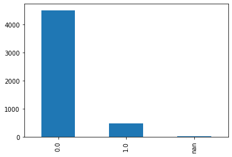

```
0.0    4500
1.0     480
NaN      20
Name: LoanOnCard, dtype: int64
```

```python
df.LoanOnCard.value_counts(dropna=False).plot(kind="bar")
plt.show()
df.LoanOnCard.value_counts(dropna=False)
```

### Its clearly show that there are null values are present in the LoanOnCard features. We have to remove it

### Class 0 has larger value than 1.

### Its a imbalance dataset

### B. Check the percentage of missing values and impute/drop if required.

```python
(df.isna().sum()/df.isnull().count())*100
```

```
ID                     0.0
Age                    0.0
CustomerSince          0.0
HighestSpend           0.0
ZipCode                0.0
HiddenScore            0.0
MonthlyAverageSpend    0.0
Level                  0.0
Mortgage               0.0
Security               0.0
FixedDepositAccount    0.0
InternetBanking        0.0
CreditCard             0.0
LoanOnCard             0.4
dtype: float64
```

#### LoanOnCard has 0.4 percentage null value

```python
df.dropna(inplace=True)
```

```python
df.info()
```

```
<class 'pandas.core.frame.DataFrame'>
Int64Index: 4980 entries, 9 to 4999
Data columns (total 14 columns):
 #   Column               Non-Null Count  Dtype
---  ------               --------------  -----
 0   ID                   4980 non-null   int64
 1   Age                  4980 non-null   int64
 2   CustomerSince        4980 non-null   int64
 3   HighestSpend         4980 non-null   int64
 4   ZipCode              4980 non-null   int64
 5   HiddenScore          4980 non-null   object
 6   MonthlyAverageSpend  4980 non-null   float64
 7   Level                4980 non-null   object
 8   Mortgage             4980 non-null   int64
 9   Security             4980 non-null   object
 10  FixedDepositAccount  4980 non-null   object
 11  InternetBanking      4980 non-null   object
 12  CreditCard           4980 non-null   object
 13  LoanOnCard           4980 non-null   float64
dtypes: float64(2), int64(6), object(6)
memory usage: 583.6+ KB
```

```python
df.isna().sum()
```

```
ID                     0
Age                    0
CustomerSince          0
HighestSpend           0
ZipCode                0
HiddenScore            0
MonthlyAverageSpend    0
Level                  0
Mortgage               0
Security               0
FixedDepositAccount    0
InternetBanking        0
CreditCard             0
LoanOnCard             0
dtype: int64
```

## C. Check for unexpected values in each categorical variable and impute with best suitable value.

```python
object_col= df.select_dtypes(include=['O']).columns
for column in object_col:
    print('Unique element of ', column ,' are ', df[column].unique())
```

```
Unique element of  HiddenScore  are  [3 1 2 4]
Unique element of  Level  are  [3 2 1]
Unique element of  Security  are  [0 1]
Unique element of  FixedDepositAccount  are  [0 1]
Unique element of  InternetBanking  are  [0 1]
Unique element of  CreditCard  are  [0 1]
```

### There is no Unexpected value in the dataset. So No need to impute it.

### If there would be some missing value, then it will be placed in unexpected_value list

```python
unexpected_value=[]  # Example unexpected_value=['!','a','3.2']
df.replace(unexpected_value, np.nan,inplace=True)
df[object_col].fillna(df[object_col].mode().iloc[0], inplace=True)
```

#### The unexpected value will be placed in the list.All the unexpected value can be put in the list.

#### After putting, it will replace the unxpected value by nan which will be further replaced by mode value

### Univariant

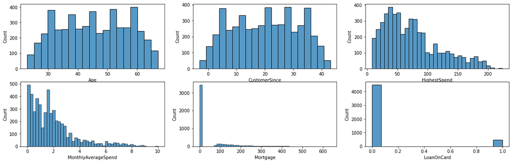

```python
fig,ax = plt.subplots(2,3, figsize=(20,6))
sns.histplot(data=df, x='Age',ax=ax[0,0])
sns.histplot(data=df, x='CustomerSince', ax=ax[0,1])
sns.histplot(data=df, x='HighestSpend', ax=ax[0,2])
sns.histplot(data=df, x='MonthlyAverageSpend', ax=ax[1,0])
sns.histplot(data=df, x='Mortgage', ax=ax[1,1])
sns.histplot(data=df, x='LoanOnCard', ax=ax[1,2])
```

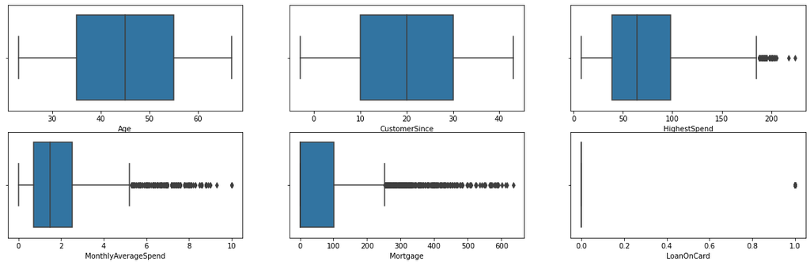

```python
fig,ax = plt.subplots(2,3, figsize=(20,6))
sns.boxplot(data=df, x='Age',ax=ax[0,0])
sns.boxplot(data=df, x='CustomerSince', ax=ax[0,1])
sns.boxplot(data=df, x='HighestSpend', ax=ax[0,2])
sns.boxplot(data=df, x='MonthlyAverageSpend', ax=ax[1,0])
sns.boxplot(data=df, x='Mortgage', ax=ax[1,1])
sns.boxplot(data=df, x='LoanOnCard', ax=ax[1,2])
```

# 3. Data Preparation and model building:

### A. Split data into X and Y.

```python
df.drop(['ID', 'ZipCode'], axis=1, inplace=True)
```

```python
X = df.drop('LoanOnCard',axis=1)
y = df[['LoanOnCard']]
```

### B. Split data into train and test. Keep 25% data reserved for testing.

```python
X_train, X_test, y_train, y_test = train_test_split(X,y, test_size=0.25, random_state=10)
```

### C. Train a Supervised Learning Classification base model - Logistic Regression.

Without Any Scaler. Check the Accuracy , AUC Score , Precision , Recall

```
trainig accuracy 0.946987951807229
testing accuracy 0.9598393574297188
auc 0.946790528643669
Classifier Report
              precision    recall  f1-score   support

         0.0       0.96      0.99      0.98      1118
         1.0       0.93      0.65      0.77       127

    accuracy                           0.96      1245
   macro avg       0.95      0.82      0.87      1245
weighted avg       0.96      0.96      0.96      1245

----------------------------------
Confusion matrix
```

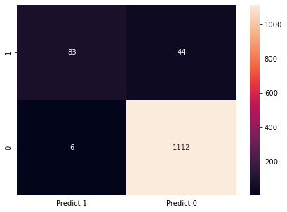

```python
labels=[1,0]
Pre_Label = ['Predict 1' ,'Predict 0']
noSc_df = pd.DataFrame()
training_acc, testing_acc, y_predict, cm, auc = printPerformanceMeasurementParameter(LogisticRegression(), X_train, y_train, X_test, y_test, labels, Pre_Label)
noSc_df[['Scaler', 'Accuracy','AUC']]= [['NO Scaler', testing_acc, auc]]
```

#### Lets Check the model with Different Scaler

### prepare model with Standar Scaler

```
trainig accuracy 0.9507362784471218
testing accuracy 0.9590361445783132
auc 0.9538123476962517
Classifier Report
              precision    recall  f1-score   support

         0.0       0.97      0.99      0.98      1118
         1.0       0.89      0.69      0.77       127

    accuracy                           0.96      1245
   macro avg       0.93      0.84      0.88      1245
weighted avg       0.96      0.96      0.96      1245

----------------------------------
Confusion matrix
```

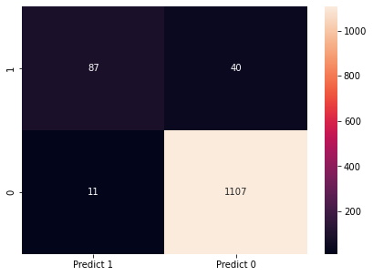

```python
stdSc_df = pd.DataFrame()
standardSclr= StandardScaler()
X_train_sc = standardSclr.fit_transform(X_train)
X_test_sc = standardSclr.transform(X_test)
training_acc, testing_acc, y_predict, cm, auc = printPerformanceMeasurementParameter(LogisticRegression(), X_train_sc, y_train, X_test_sc, y_test, labels, Pre_Label)
stdSc_df[['Scaler', 'Accuracy','AUC']]= [['Standar Scaler', testing_acc, auc]]
```

#### Accuracy of Model is around 95% for training and testing data. But data is imbalance

### 11 has been identified as False positve

### 40 has been identfied as False Negative

### Out of total Category 1 count (40+87) , only 87as been correctly identified.

### Recal of category 1 is less i.e 0.69.

### Recall is good for category 0

### F1 score is less for category 1 and good for Cateogory 0

#### Prepare model with robust scaler

```
trainig accuracy 0.9491298527443106
testing accuracy 0.9582329317269076
auc 0.953896863071007
Classifier Report
              precision    recall  f1-score   support

         0.0       0.96      0.99      0.98      1118
         1.0       0.89      0.67      0.77       127

    accuracy                           0.96      1245
   macro avg       0.93      0.83      0.87      1245
weighted avg       0.96      0.96      0.96      1245

----------------------------------
Confusion matrix
```

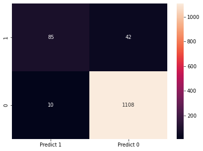

```python
rbSc_df = pd.DataFrame()
rbScaler= RobustScaler()
X_train_rb = rbScaler.fit_transform(X_train)
X_test_rb = rbScaler.transform(X_test)
training_acc, testing_acc, y_predict, cm, auc = printPerformanceMeasurementParameter(LogisticRegression(), X_train_rb, y_train, X_test_rb, y_test, labels, Pre_Label)
rbSc_df[['Scaler', 'Accuracy','AUC']]= [['Robust Scaler', testing_acc, auc]]
```

#### Prepare model with MinMax scaler

```
trainig accuracy 0.9504685408299867
testing accuracy 0.9566265060240964
auc 0.9542419675179243
Classifier Report
              precision    recall  f1-score   support

         0.0       0.96      0.99      0.98      1118
         1.0       0.93      0.62      0.75       127

    accuracy                           0.96      1245
   macro avg       0.94      0.81      0.86      1245
weighted avg       0.96      0.96      0.95      1245

----------------------------------
Confusion matrix
```

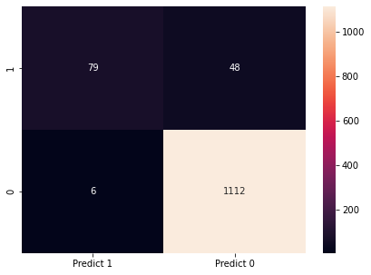

```python
mmSc_df = pd.DataFrame()
mmScaler= MinMaxScaler()
X_train_mm = mmScaler.fit_transform(X_train)
X_test_mm = mmScaler.transform(X_test)
training_acc, testing_acc, y_predict, cm, auc = printPerformanceMeasurementParameter(LogisticRegression(), X_train_mm, y_train, X_test_mm, y_test, labels, Pre_Label)
mmSc_df[['Scaler', 'Accuracy','AUC']]= [['MinMax Scaler', training_acc, auc]]
```

#### Checking the ACcuracy and AUC SCore

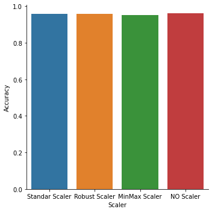

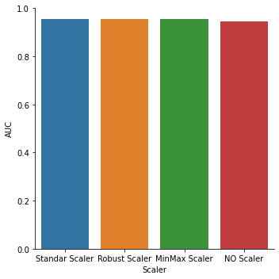

```python
stdSc_df= stdSc_df.append([rbSc_df,mmSc_df,noSc_df])
sns.catplot(x="Scaler", y="Accuracy", kind="bar", data=stdSc_df)
plt.show()
sns.catplot(x="Scaler", y="AUC", kind="bar", data=stdSc_df)
plt.show()
```

#### With StandardScaling, RobustScaling and MinMaxScaling no Scaling, we are gettting the almost same accuracy and same AUC.

### E. Balance the data using the right balancing technique.

# Find the total number of element in each category of LoanOnCard feature

```python
df.LoanOnCard.value_counts()
```

```
0.0    4500
1.0     480
Name: LoanOnCard, dtype: int64
```

# Find the percentage of element in each category class of LoanOnCard feature on Training data

```python
y_train.value_counts()
```

```
LoanOnCard
0.0           3382
1.0            353
dtype: int64
```

```python
y_train.value_counts(normalize=True)
```

```
LoanOnCard
0.0           0.905489
1.0           0.094511
dtype: float64
```

The LoanOnCard feature has class 0 : 90.54% and Class 1 has only 9.4%

```python
from imblearn.over_sampling import SMOTE
sm = SMOTE(random_state = 2)
X_train_balance, y_train_balance = sm.fit_sample(X_train, y_train.values.ravel())
```

```python
print("Total 0 class number", sum(y_train_balance==0))
print("Total 1 class number", sum(y_train_balance==1))
```

```
Total 0 class number 3382
Total 1 class number 3382
```

#### Now the data is 50:50 ratio. SMOTE is performed to increase the class 1 data in training data

### F. Again train the same previous model on balanced data.

Without Scaling

```
trainig accuracy 0.9055292726197516
testing accuracy 0.8835341365461847
auc 0.9496640513853478
Classifier Report
              precision    recall  f1-score   support

         0.0       0.98      0.89      0.93      1118
         1.0       0.46      0.87      0.60       127

    accuracy                           0.88      1245
   macro avg       0.72      0.88      0.77      1245
weighted avg       0.93      0.88      0.90      1245

----------------------------------
Confusion matrix
```

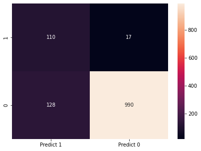

```python
training_acc, testing_acc, y_predict, cm, auc = printPerformanceMeasurementParameter(LogisticRegression(), X_train_balance, y_train_balance, X_test, y_test, labels, Pre_Label)
```

### Comparing with non balance data model with Balance data model

### with no Scaling of data in both model

### Accuracy is gone down from 95.9% to 88.3% (around 7%)

### Recall of class 1 increase from 0.65 to 0.87.

### F1 and Precision down are down for class 1 .

```
trainig accuracy 0.9093731519810763
testing accuracy 0.8891566265060241
auc 0.9563055512515318
Classifier Report
              precision    recall  f1-score   support

         0.0       0.99      0.89      0.94      1118
         1.0       0.48      0.89      0.62       127

    accuracy                           0.89      1245
   macro avg       0.73      0.89      0.78      1245
weighted avg       0.93      0.89      0.90      1245

----------------------------------
Confusion matrix
```

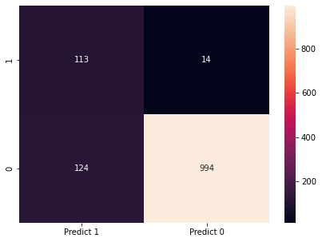

```python
standardSclr= StandardScaler()
X_train_balance_sc = standardSclr.fit_transform(X_train_balance)
X_test_balance_sc = standardSclr.transform(X_test)
training_acc, testing_acc, y_predict, cm, auc = printPerformanceMeasurementParameter(LogisticRegression(), X_train_balance_sc, y_train_balance, X_test_balance_sc, y_test, labels, Pre_Label)
```

### Comparing with previous Standard Scaling model with current Standard Scaling

### Accuracy is gone down from 95.9% to 88.9% (around 7%)

### Recall of class 1 increase from 0.69 to 0.89.

### F1 and Precision of class 1 are down. Precision down of class 1 from 0.89 to 0.48 and F1 from 0.77 to 0.62

### With RobustScaler

```
trainig accuracy 0.908929627439385
testing accuracy 0.8891566265060241
auc 0.9566647415942416
Classifier Report
              precision    recall  f1-score   support

         0.0       0.99      0.89      0.94      1118
         1.0       0.48      0.90      0.62       127

    accuracy                           0.89      1245
   macro avg       0.73      0.89      0.78      1245
weighted avg       0.94      0.89      0.90      1245

----------------------------------
Confusion matrix
```

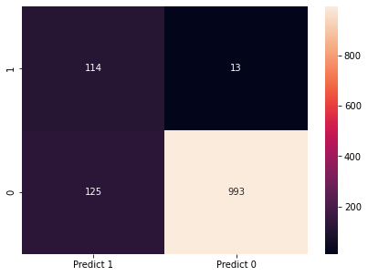

```python
rbScaler= RobustScaler()
X_train_balance_rb = rbScaler.fit_transform(X_train_balance)
X_test_balance_rb = rbScaler.transform(X_test)
training_acc, testing_acc, y_predict, cm, auc = printPerformanceMeasurementParameter(LogisticRegression(), X_train_balance_rb, y_train_balance, X_test_balance_rb, y_test, labels, Pre_Label)
```

### Recall increase of class 1 from 0.67 to 0.90.

### F1 is down for class 1 from 0.77 to 0.62.

### Precision is down for class 1 from 0.89 to 0.48

# 4. Performance Improvement:

#### Logistic Regression on Standard Scaling data

```
trainig accuracy 0.9093731519810763
testing accuracy 0.8891566265060241
auc 0.9563055512515318
Classifier Report
              precision    recall  f1-score   support

         0.0       0.99      0.89      0.94      1118
         1.0       0.48      0.89      0.62       127

    accuracy                           0.89      1245
   macro avg       0.73      0.89      0.78      1245
weighted avg       0.93      0.89      0.90      1245

----------------------------------
Confusion matrix
```

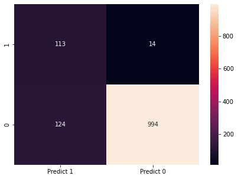

```python
training_acc, testing_acc, y_predict, cm, auc = printPerformanceMeasurementParameter(LogisticRegression(), X_train_balance_sc, y_train_balance, X_test_balance_sc, y_test, labels, Pre_Label)
```

#### Linear SVM Kernal With Standard Scaling data

```
trainig accuracy 0.9092253104671791
testing accuracy 0.8763052208835341
auc 0.9561506063978139
Classifier Report
              precision    recall  f1-score   support

         0.0       0.99      0.87      0.93      1118
         1.0       0.45      0.91      0.60       127

    accuracy                           0.88      1245
   macro avg       0.72      0.89      0.76      1245
weighted avg       0.93      0.88      0.89      1245

----------------------------------
Confusion matrix
```

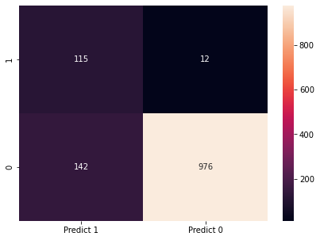

```python
training_acc, testing_acc, y_predict, cm, auc = printPerformanceMeasurementParameter(SVC(kernel="linear",probability=True), X_train_balance_sc, y_train_balance, X_test_balance_sc, y_test, labels, Pre_Label)
```

#### RBF SVM Kernal With Standard Scaling data

```
trainig accuracy 0.9880248373743347
testing accuracy 0.9734939759036144
auc 0.9834279436000732
Classifier Report
              precision    recall  f1-score   support

         0.0       0.99      0.98      0.99      1118
         1.0       0.84      0.91      0.88       127

    accuracy                           0.97      1245
   macro avg       0.92      0.95      0.93      1245
weighted avg       0.97      0.97      0.97      1245

----------------------------------
Confusion matrix
```

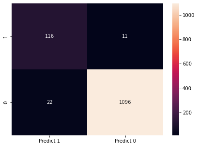

```python
training_acc, testing_acc, y_predict, cm, auc = printPerformanceMeasurementParameter(SVC(kernel="rbf",probability=True), X_train_balance_sc, y_train_balance, X_test_balance_sc, y_test, labels, Pre_Label)
```

### K Nearest Classifer with standard Scaling Data.

```
trainig accuracy 0.9878769958604376
testing accuracy 0.951004016064257
auc 0.943621202090347
Classifier Report
              precision    recall  f1-score   support

         0.0       0.98      0.97      0.97      1118
         1.0       0.74      0.81      0.77       127

    accuracy                           0.95      1245
   macro avg       0.86      0.89      0.87      1245
weighted avg       0.95      0.95      0.95      1245

----------------------------------
Confusion matrix
```

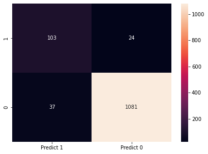

```python
training_acc, testing_acc, y_predict, cm, auc = printPerformanceMeasurementParameter(KNeighborsClassifier(), X_train_balance_sc, y_train_balance, X_test_balance_sc, y_test, labels, Pre_Label)
```

### Observation : RBF SVM kernal is giving best accuracy of 97.3% compare to K nearest Neighbor 95%. . Performing hyperparameter tuning of SVM and K Nearest neigbor model to get the best model

### B. Tune parameters for each of the models wherever required and finalize a model.

Finding the best parameter for SVM model using GridSearchCV

```python
hyper_parameters = dict(C=[1,5,10,100], kernel= ['linear','rbf'],gamma = 10.0**np.arange(-2,3))
model = GridSearchCV(SVC(), hyper_parameters, cv=5)
model.fit(X_train_balance_sc, y_train_balance)
y_pred_balance = model.predict(X_test_balance_sc);
#Check performance using accuracy
print("Accuracy : ", accuracy_score(y_test, y_pred_balance))
#Best Hyperparameters Value
print("Best Parameters : ", model.best_params_)
```

```
Accuracy :  0.9566265060240964
Best Parameters :  {'C': 5, 'gamma': 1.0, 'kernel': 'rbf'}
```

### Out of Linear and RBF model, RBF is giving performance. So taking RBF into account

```
trainig accuracy 0.9997043169722057
testing accuracy 0.9566265060240964
auc 0.9733565281084051
Classifier Report
              precision    recall  f1-score   support

         0.0       0.96      0.99      0.98      1118
         1.0       0.90      0.65      0.75       127

    accuracy                           0.96      1245
   macro avg       0.93      0.82      0.86      1245
weighted avg       0.95      0.96      0.95      1245

----------------------------------
Confusion matrix
```

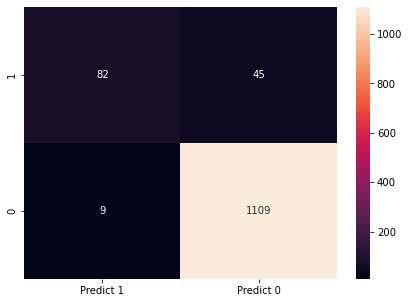

```python
rbf_svc = SVC(C=5 , kernel= "rbf", gamma=1.0, probability=True)
training_acc, testing_acc, y_predict, cm, auc = printPerformanceMeasurementParameter(rbf_svc, X_train_balance_sc, y_train_balance, X_test_balance_sc, y_test, labels, Pre_Label)
```

### Accuracy is 95.6%

### Recall, precision and f1-score of category 0 are 96%, 99%, and 98%

### Recall, precision and f1-score of category 1 are 90%, 65% and 75%

### Finding the Best value of K neigbors

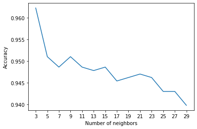

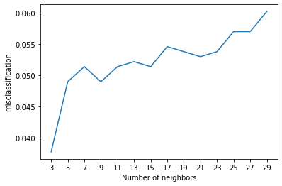

```python
N_neigbours = list(np.arange(3,30,2))
score = []
misclassification = []
for n in N_neigbours:
    knn = KNeighborsClassifier(n_neighbors=n)
    knn.fit(X_train_balance_sc, y_train_balance)
    sc = knn.score(X_test_balance_sc, y_test);
    score.append(sc)
    misclassification.append(1-sc)
plt.plot(N_neigbours, score);
plt.xticks(N_neigbours);
plt.xlabel("Number of neighbors")
plt.ylabel("Accuracy")
plt.show()
plt.plot(N_neigbours, misclassification);
plt.xticks(N_neigbours);
plt.xlabel("Number of neighbors")
plt.ylabel("misclassification")
plt.show()
```

#### According to the graph, we observed that K =3 is the best value in which Accuracy is high and misclassification is low.

Using GridSearchCV finding the best parameter for KNN Model

```python
hyper_parameters = dict(n_neighbors = N_neigbours, weights= ['distance', 'uniform'],p = [1,2])
model = GridSearchCV(KNeighborsClassifier(), hyper_parameters, cv=5)
model.fit(X_train_balance_sc, y_train_balance)
y_pred_balance = model.predict(X_test_balance_sc);
#Check performance using accuracy
print("Testing accuracy", accuracy_score(y_test, y_pred_balance))
#Best Hyperparameters Value
print("Best Parameters : ", model.best_params_)
```

```
Testing accuracy 0.9662650602409638
Best Parameters :  {'n_neighbors': 5, 'p': 1, 'weights': 'distance'}
```

### Using hyperparameter and GridSearchCV, the nearest neigbor value is 5 which accuracy of 96.6%

```
trainig accuracy 1.0
testing accuracy 0.9662650602409638
auc 0.9346625723662897
Classifier Report
              precision    recall  f1-score   support

         0.0       0.98      0.99      0.98      1118
         1.0       0.88      0.78      0.82       127

    accuracy                           0.97      1245
   macro avg       0.93      0.88      0.90      1245
weighted avg       0.97      0.97      0.97      1245

----------------------------------
Confusion matrix
```

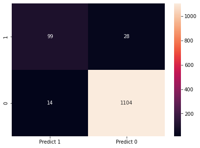

```python
knn = KNeighborsClassifier(n_neighbors=5, p= 1, weights='distance')
training_acc, testing_acc, y_predict, cm, auc = printPerformanceMeasurementParameter(knn, X_train_balance_sc, y_train_balance, X_test_balance_sc, y_test, labels, Pre_Label)
```

### Final Model will be KNearest Neighbor

### C. Print evaluation metrics for final model.

```
trainig accuracy 1.0
testing accuracy 0.9662650602409638
auc 0.9346625723662897
Classifier Report
              precision    recall  f1-score   support

         0.0       0.98      0.99      0.98      1118
         1.0       0.88      0.78      0.82       127

    accuracy                           0.97      1245
   macro avg       0.93      0.88      0.90      1245
weighted avg       0.97      0.97      0.97      1245

----------------------------------
Confusion matrix
```

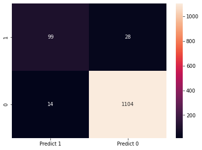

```python
knn = KNeighborsClassifier(n_neighbors=5, p= 1, weights='distance')
training_acc, testing_acc, y_predict, cm, auc = printPerformanceMeasurementParameter(knn, X_train_balance_sc, y_train_balance, X_test_balance_sc, y_test, labels, Pre_Label)
```

# D. Share improvement achieved from base model to final model

### Comparing result of logistics model With Balance data and using Standard Scaler Model

### Accuracy of Logistics Regression is 88.9% with balance data but in KNN model, accuracy is 96.6% [IMPROVED]

### Recall Score of class 0 in Logistics Regression is 89% but in KNN model, accuracy is 99% [IMPROVED]

### Recall Score of class 1 in Logistics Regression was 89% but in KNN model, accuracy is 78% [DECREASE]

### precision Score of class 0 in Logistics Regression is 99% but in KNN model, accuracy is 98% [ALMOST_EQUAL]

### precision Score of class 1 in Logistics Regression is 48% but in KNN model, accuracy is 88%[IMPROVED]

### f1-score of class 0 in Logistics Regression is 94% but in KNN, accuracy is 98% [IMPROVED]

### f1-score Score of class 1 in Logistics Regression is 62% but in KNN, accuracy is 82%[IMPROVED]